# GSS challange More Data

Jennifer Contreras

Novermber 25th 2026

# Introduction

Is attitude toward capitol punishment (cappun) independent of race (race)? If not, then whose view differs from whom??

Based of the dataset GSS, is the attitude toward capitol punishment independent from the race of the individual?

$H_0$: There is no relationship between the attitude of an individual towards capitol punishment and their race.

$H_A$: There is a relationship between the attitude of an individual towards capitol punishment and their race.

# Methods

Attitude towards Capitol Punishment is categorical.

Race is categorical.

# Results

## Descriptive Results

### Graphical Descriptive Results

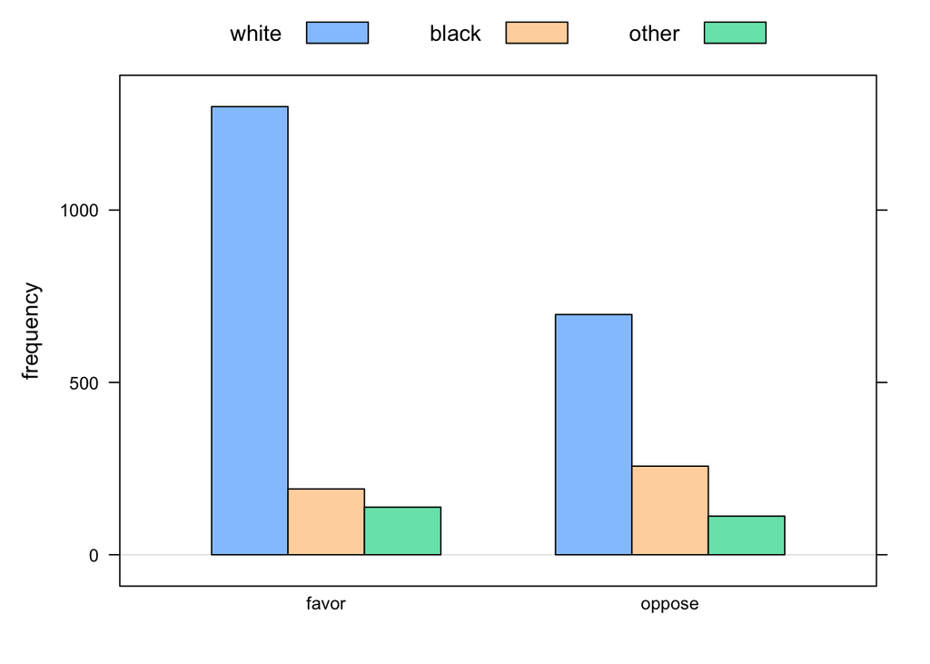

```r
barchartGC(~cappun + race,data=GSS)
```

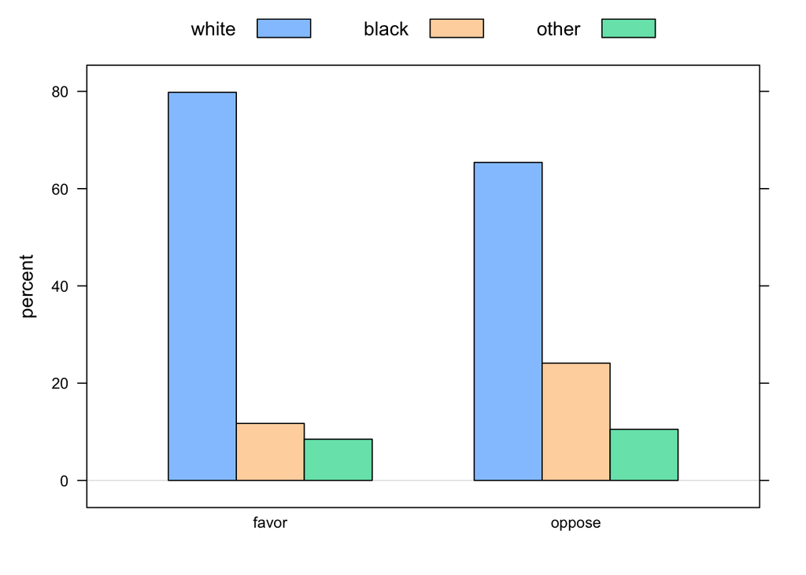

```r
barchartGC(~cappun + race,data=GSS, type="percent")
```

According to this bar chart, there was a higher percentage of white individuals that favored capitol punishment over those who opposed it. The bar chart also shows that a higher percentage of black individuals opposed capitol punishment over those who favored it. As for the other category, the percentage of those who opposed and favored capitol punishment were closer in percentages.

## Now with The Most data (fewer variables gives more data points)

### Numerical Descriptive Results

```r
table1 <- xtabs(~cappun + race, data=GSS)
rowPerc(table1)
```

```
##         race
## cappun    white  black  other  Total
##   favor   79.80  11.72   8.47 100.00
##   oppose  65.38  24.11  10.51 100.00
```

```r
colPerc(table1)
```

```
##         race
## cappun   white  black other
##   favor   65.1  42.63  55.2
##   oppose  34.9  57.37  44.8
##   Total  100.0 100.00 100.0
```

## Inferential Results

```r
chisq.test(table1)
```

```
##
##  Pearson's Chi-squared test
##
## data:  table1
## X-squared = 80.4, df = 2, p-value < 2.2e-16
```

```r
chisqtestGC(table1)
```

```
## Pearson's Chi-squared test
##
## Observed Counts:
##         race
## cappun   white black other
##   favor   1300   191   138
##   oppose   697   257   112
##
## Counts Expected by Null:
##         race
## cappun     white  black  other
##   favor  1207.09 270.79 151.11
##   oppose  789.91 177.21  98.89
##
## Contributions to the chi-square statistic:
##         race
## cappun   white black other
##   favor   7.15 23.51  1.14
##   oppose 10.93 35.93  1.74
##
##
## Chi-Square Statistic = 80.3999
## Degrees of Freedom of the table = 2
## P-Value = 0
```

```r
fisher.test(table1)
```

```
##
##  Fisher's Exact Test for Count Data
##
## data:  table1
## p-value < 2.2e-16
## alternative hypothesis: two.sided
```

The p-value is 0.00000000000000022 which is less than 0.05. This means we will reject the null hypothesis and that we conclude that there is a relationship between an individuals attitude towards capitol punishment and the race of the individual.

## More data version

```r
fisherXY(GSS$cappun,GSS$race,confL=0.05)
```

```
##
## contingency table:
##         y
## x        white black other
##   favor   1300   191   138
##   oppose   697   257   112
##
## ***All 2X2 tests****
##
## [1] "favor"  "oppose"
## [1] "white" "black"
##         y
## x        white black
##   favor   1300   191
##   oppose   697   257
##
##  Fisher's Exact Test for Count Data
##
## data:  fTempTable
## p-value < 2.2e-16
## alternative hypothesis: true odds ratio is not equal to 1
## 5 percent confidence interval:
##  2.477294 2.539321
## sample estimates:
## odds ratio
##   2.508637
##
##
## [1] "favor"  "oppose"
## [1] "white" "other"
##         y
## x        white other
##   favor   1300   138
##   oppose   697   112
##
##  Fisher's Exact Test for Count Data
##
## data:  fTempTable
## p-value = 0.002607
## alternative hypothesis: true odds ratio is not equal to 1
```

[output cut: 9 more lines]

```
##         y
## x        black other
##   favor    191   138
##   oppose   257   112
##
##  Fisher's Exact Test for Count Data
##
## data:  fTempTable
## p-value = 0.001564
## alternative hypothesis: true odds ratio is not equal to 1
## 5 percent confidence interval:
##  0.5902965 0.6175220
## sample estimates:
## odds ratio
##  0.6036291
```

The fisherXY test displays that all races have a difference in their attitude towards capitol punishment as each of the races displayed have a p-value that is less than 0.05. The p-value of white and black is 0.00000000000000022. The p-value of white and other is 0.002607. The p-value of black and other is 0.001564. As is shown, the p-values are less than 0.05 and therefore we can reject the null hypothesis. Each also have different odd ratios.

# Discussion and Conclusion

Is the attitude of an individual toward capitol punishment independent from their race?

Based off of the information gathered from tests and plots performed, we reject the null hypothesis as the p-value resulted in the values below 0.05. The fisherXY test showed that each race is different regarding their attitude towards capitol punishment. The results p-values of the different races included 0.002607, 0.001564, and 0.00000000000000022. This is why we can reject the null hypothesis. We can conclude that there is a relationship between the attitude of an individual towards capitol punishment and race. The data displayed that there were higher percentages of white individuals favoring capitol punishment, higher percentages of black individuals opposing capitol punishment, and a close percentage of other race individuals regarding favoring or opposing capitol punishment.